# Regressão Logística

Falo de Regressão Linear desde o começo desse blog porque é um dos primeiros tópicos em modelagem estatística. Não menos importante, acredito que regressão logística seria o segundo passo para quem quer realmente fazer modelos. Se você já se aproximou de alguma forma de modelagem estatística, você com certeza já ouviu falar dela.

O motivo dessa regressão ser ensinada e ter tanto foco é simples, ela traz a resposta de questões que precisamos responder no mundo de crédito, vendas, etc. Uma das coisas que mais gostaríamos de saber quando trabalhamos com crédito é se o cliente vai pagar ou não o dinheiro que tomou emprestado. Veja que a variável resposta aqui é se o cliente paga ou não o crédito, é binária: sim ou não.

Enquanto na regressão linear temos uma variável resposta contínua (e.g.: o valor da dívida), na regressão logística nossa variável resposta é binária, 0 ou 1.

Vamos supor que você emprestou dinheiro para um colega. Há dois eventos possíveis desse empréstimo: seu amigo paga ou não. Se o seu amigo tiver um bom salário, um emprego estável e um histórico impecável, é provável que ele te pague. Agora, se ele estiver desempregado, tiver fama de caloteiro e estiver atolado em dívidas, a probabilidade de ele não pagar é maior. Pois é isso que a regressão logística (ou o logit) vai te proporcionar.

##### **Assim como Árvore de Decisão, é simples de entender e fácil de se implementar.**

A saída do Logit não é exatamente a probabilidade, mas te leva a ela através do odds ratio:

logit(p) = ln(p/(1-p)) ln(odds) = ln(p/(1-p)) odds = p/ (1-p)

Sendo p = probabilidade de ocorrência do evento e 1-p = probabilidade de não ocorrência

##### **Alguns pontos que valem mencionar:**

Na regressão logística não assumimos uma relação linear entre a variável dependente e independente;

Erros não têm distribuição normal;

Utilizamos a máxima verossimilhança, e não mínimos quadrados.

**—————————————————————————–**

Regressão logística é uma técnica estatística muito poderosa, utilizada para modelagem de saídas binárias (sim ou não). Quando se quer medir a relação de uma variável dependente binária com uma ou mais variáveis independentes, é comum utilizar esta técnica. Pense, por exemplo, numa empresa que empresta dinheiro para um cliente. Com base nas informações deste cliente (idade, profissão, etc.), é interessante a empresa tentar prever se o cliente vai pagar a dívida ou não. Uma forma de tentar prever isso é utilizando a regressão logística.

Neste post, vamos entender como construir uma regressão logística no R. Claro, é importante ter conhecimento da matemática por trás desta técnica. Mas isso deixarei para outro post. Por enquanto, vamos nos focar na execução. Sei que não é a melhor forma de ensinar, mas como já tenho o código preparado, acho que postar de imediato pode ser útil para quem já entende o conceito. Um pouco mais sobre a regressão logística, você pode encontrar no post Regressão Logística: Primeiros Passos.

Vamos construir nossa regressão logística utilizando como exemplo os dados de spam. Inicialmente, vamos carregar o pacote kernlab e os dados de spam:

**—————————————————————————–**

### Pacotes usados:

kernlab, caret e ROCR;

**—————————————————————————–**

Como você pode não saber exatamente o que há dentro de spam, é importante verificar algumas coisas, como as primeiras linhas da tabela, o total de linhas e colunas, uma estatística descritiva resumida:

```r
data(spam)
head(spam)
```

```
##   make address  all num3d  our over remove internet order mail receive
## 1 0.00    0.64 0.64     0 0.32 0.00   0.00     0.00  0.00 0.00    0.00
## 2 0.21    0.28 0.50     0 0.14 0.28   0.21     0.07  0.00 0.94    0.21
## 3 0.06    0.00 0.71     0 1.23 0.19   0.19     0.12  0.64 0.25    0.38
## 4 0.00    0.00 0.00     0 0.63 0.00   0.31     0.63  0.31 0.63    0.31
## 5 0.00    0.00 0.00     0 0.63 0.00   0.31     0.63  0.31 0.63    0.31
## 6 0.00    0.00 0.00     0 1.85 0.00   0.00     1.85  0.00 0.00    0.00
##   will people report addresses free business email  you credit your font
## 1 0.64   0.00   0.00      0.00 0.32     0.00  1.29 1.93   0.00 0.96    0
## 2 0.79   0.65   0.21      0.14 0.14     0.07  0.28 3.47   0.00 1.59    0
## 3 0.45   0.12   0.00      1.75 0.06     0.06  1.03 1.36   0.32 0.51    0
## 4 0.31   0.31   0.00      0.00 0.31     0.00  0.00 3.18   0.00 0.31    0
## 5 0.31   0.31   0.00      0.00 0.31     0.00  0.00 3.18   0.00 0.31    0
## 6 0.00   0.00   0.00      0.00 0.00     0.00  0.00 0.00   0.00 0.00    0
##   num000 money hp hpl george num650 lab labs telnet num857 data num415
```

[output cut: 34 more lines]

```r
dim(spam)
```

```
## [1] 4601   58
```

```r
summary(spam)
```

```
##       make           address            all             num3d
##  Min.   :0.0000   Min.   : 0.000   Min.   :0.0000   Min.   : 0.00000
##  1st Qu.:0.0000   1st Qu.: 0.000   1st Qu.:0.0000   1st Qu.: 0.00000
##  Median :0.0000   Median : 0.000   Median :0.0000   Median : 0.00000
##  Mean   :0.1046   Mean   : 0.213   Mean   :0.2807   Mean   : 0.06542
##  3rd Qu.:0.0000   3rd Qu.: 0.000   3rd Qu.:0.4200   3rd Qu.: 0.00000
##  Max.   :4.5400   Max.   :14.280   Max.   :5.1000   Max.   :42.81000
##       our               over            remove          internet
##  Min.   : 0.0000   Min.   :0.0000   Min.   :0.0000   Min.   : 0.0000
##  1st Qu.: 0.0000   1st Qu.:0.0000   1st Qu.:0.0000   1st Qu.: 0.0000
##  Median : 0.0000   Median :0.0000   Median :0.0000   Median : 0.0000
##  Mean   : 0.3122   Mean   :0.0959   Mean   :0.1142   Mean   : 0.1053
##  3rd Qu.: 0.3800   3rd Qu.:0.0000   3rd Qu.:0.0000   3rd Qu.: 0.0000
##  Max.   :10.0000   Max.   :5.8800   Max.   :7.2700   Max.   :11.1100
##      order              mail            receive             will
##  Min.   :0.00000   Min.   : 0.0000   Min.   :0.00000   Min.   :0.0000
##  1st Qu.:0.00000   1st Qu.: 0.0000   1st Qu.:0.00000   1st Qu.:0.0000
##  Median :0.00000   Median : 0.0000   Median :0.00000   Median :0.1000
##  Mean   :0.09007   Mean   : 0.2394   Mean   :0.05982   Mean   :0.5417
##  3rd Qu.:0.00000   3rd Qu.: 0.1600   3rd Qu.:0.00000   3rd Qu.:0.8000
##  Max.   :5.26000   Max.   :18.1800   Max.   :2.61000   Max.   :9.6700
##      people            report           addresses           free
##  Min.   :0.00000   Min.   : 0.00000   Min.   :0.0000   Min.   : 0.0000
##  1st Qu.:0.00000   1st Qu.: 0.00000   1st Qu.:0.0000   1st Qu.: 0.0000
##  Median :0.00000   Median : 0.00000   Median :0.0000   Median : 0.0000
##  Mean   :0.09393   Mean   : 0.05863   Mean   :0.0492   Mean   : 0.2488
##  3rd Qu.:0.00000   3rd Qu.: 0.00000   3rd Qu.:0.0000   3rd Qu.: 0.1000
##  Max.   :5.55000   Max.   :10.00000   Max.   :4.4100   Max.   :20.0000
##     business          email             you             credit
##  Min.   :0.0000   Min.   :0.0000   Min.   : 0.000   Min.   : 0.00000
##  1st Qu.:0.0000   1st Qu.:0.0000   1st Qu.: 0.000   1st Qu.: 0.00000
##  Median :0.0000   Median :0.0000   Median : 1.310   Median : 0.00000
##  Mean   :0.1426   Mean   :0.1847   Mean   : 1.662   Mean   : 0.08558
##  3rd Qu.:0.0000   3rd Qu.:0.0000   3rd Qu.: 2.640   3rd Qu.: 0.00000
##  Max.   :7.1400   Max.   :9.0900   Max.   :18.750   Max.   :18.18000
##       your              font             num000           money
##  Min.   : 0.0000   Min.   : 0.0000   Min.   :0.0000   Min.   : 0.00000
##  1st Qu.: 0.0000   1st Qu.: 0.0000   1st Qu.:0.0000   1st Qu.: 0.00000
##  Median : 0.2200   Median : 0.0000   Median :0.0000   Median : 0.00000
##  Mean   : 0.8098   Mean   : 0.1212   Mean   :0.1016   Mean   : 0.09427
```

[output cut: 50 more lines]

```
##  Max.   :4.38500   Max.   :9.752    Max.   :4.08100   Max.   :32.4780
##    charDollar         charHash          capitalAve        capitalLong
##  Min.   :0.00000   Min.   : 0.00000   Min.   :   1.000   Min.   :   1.00
##  1st Qu.:0.00000   1st Qu.: 0.00000   1st Qu.:   1.588   1st Qu.:   6.00
##  Median :0.00000   Median : 0.00000   Median :   2.276   Median :  15.00
##  Mean   :0.07581   Mean   : 0.04424   Mean   :   5.191   Mean   :  52.17
##  3rd Qu.:0.05200   3rd Qu.: 0.00000   3rd Qu.:   3.706   3rd Qu.:  43.00
##  Max.   :6.00300   Max.   :19.82900   Max.   :1102.500   Max.   :9989.00
##   capitalTotal          type
##  Min.   :    1.0   nonspam:2788
##  1st Qu.:   35.0   spam   :1813
##  Median :   95.0
##  Mean   :  283.3
##  3rd Qu.:  266.0
##  Max.   :15841.0
```

```r
spam$type_new = ifelse(spam$type == "spam", 1, 0)
```

Como você pode ver, temos 58 colunas e 4.601 linhas. A base tem diversas características de e-mails (e.g.: quantidade de letras maiúsculas, quantidade de ponto e vírgula, etc.) e uma coluna marcando se o e-mail é um spam ou não. Ou seja, temos um histórico de e-mails, as informações deles e se o e-mail é um spam ou não. Com isso, podemos tentar construir um modelo que seja capaz de prever se um e-mail é um spam ou não, com base em algumas características.

Em primeiro lugar, precisamos separar a base treino e teste. Para facilitar o trabalho, vamos carregar o pacote caret que possui várias funções de modelagem. Em seguida, utilizamos a função createDataPartition para separar a base de forma aleatória na proporção 75-25. Com base na separação feita, criamos a base treino e o que não estiver nela será a base teste:

```r
indice.treino <- createDataPartition(y = spam$type,
                                     p = 0.75,
                                     list = FALSE)
treino = spam[ indice.treino, ]
teste  = spam[-indice.treino, ]
```

Você pode, e deve, fazer algumas análises na sua base. Por exemplo, temos algum missing nela?

```r
sapply(treino,
       function(x) sum(is.na(x)))
```

```
##              make           address               all             num3d
##                 0                 0                 0                 0
##               our              over            remove          internet
##                 0                 0                 0                 0
##             order              mail           receive              will
##                 0                 0                 0                 0
##            people            report         addresses              free
##                 0                 0                 0                 0
##          business             email               you            credit
##                 0                 0                 0                 0
##              your              font            num000             money
##                 0                 0                 0                 0
##                hp               hpl            george            num650
##                 0                 0                 0                 0
##               lab              labs            telnet            num857
##                 0                 0                 0                 0
##              data            num415             num85        technology
##                 0                 0                 0                 0
##           num1999             parts                pm            direct
##                 0                 0                 0                 0
##                cs           meeting          original           project
##                 0                 0                 0                 0
##                re               edu             table        conference
##                 0                 0                 0                 0
##     charSemicolon  charRoundbracket charSquarebracket   charExclamation
##                 0                 0                 0                 0
##        charDollar          charHash        capitalAve       capitalLong
##                 0                 0                 0                 0
##      capitalTotal              type          type_new
##                 0                 0                 0
```

Note que, para nossa sorte, não há nenhum NA na base inteira. Se houvesse, poderíamos trata-los de diversas formas: excluindo as linhas, preenchendo-as com a média da coluna a qual pertence, preenchendo-a através do método KNN, etc.

Poderíamos, também, fazer uma análise gráfica. Porém, você pode ver diversos tutoriais de gráficos no R e aplicá-los aqui (veja Gráficos em R, Personalizando seu gráfico do ggplot2 – Exports and Imports, William Playfair, Mais gráficos no R: qqplot(), Histograma no R).

**Vamos então ao modelo:**

```r
modelo = glm(type_new ~ our + over + remove,
             data   = treino,
             family = binomial)
summary(modelo)
```

```
##
## Call:
## glm(formula = type_new ~ our + over + remove, family = binomial,
##     data = treino)
##
## Deviance Residuals:
##     Min       1Q   Median       3Q      Max
## -5.6177  -0.7360  -0.7360   0.8535   1.6962
##
## Coefficients:
##             Estimate Std. Error z value Pr(>|z|)
## (Intercept) -1.16773    0.04823 -24.213   <2e-16 ***
## our          0.69926    0.07373   9.484   <2e-16 ***
## over         2.08936    0.19772  10.567   <2e-16 ***
## remove       5.52021    0.44421  12.427   <2e-16 ***
## ---
## Signif. codes:  0 '***' 0.001 '**' 0.01 '*' 0.05 '.' 0.1 ' ' 1
##
## (Dispersion parameter for binomial family taken to be 1)
##
##     Null deviance: 4628.1  on 3450  degrees of freedom
## Residual deviance: 3661.9  on 3447  degrees of freedom
## AIC: 3669.9
##
## Number of Fisher Scoring iterations: 7
```

Veja que as todas as variáveis são estatisticamente significantes. Você poderia ainda utilizar o stepwise na seleção de variáveis, bastaria rodar step(modelo). No stepwise, as variáveis vão sendo testadas e mantidas de acordo com sua significância.

**Se você quiser ver os coeficientes da regressão:**

```r
summary(modelo)$coefficients
```

```
##               Estimate Std. Error    z value      Pr(>|z|)
## (Intercept) -1.1677264 0.04822772 -24.212766 1.632469e-129
## our          0.6992583 0.07372979   9.484066  2.445628e-21
## over         2.0893638 0.19771758  10.567416  4.219623e-26
## remove       5.5202081 0.44420988  12.427027  1.864404e-35
```

Lembre-se, os coeficientes de uma regressão logística não são como os de uma regressão linear. Enquanto na regressão linear tínhamos algo como y = beta0 + beta1.x, na regressão logística temos log(p/1-p) = beta0 + beta1.x. Não é necessário, mas você poderia, por causa disso, calcular agora o odds ratio (veja também Regressão Logística: Primeiros Passos):

```r
odd.ratio = exp(coef(modelo))
```

Seria um outro jeito de ler a equação.

Agora, usamos a função predict para aplicar o modelo em nossa base teste e já aproveitamos para criar uma nova base teste com as projeções feitas pelo modelo:

```r
pred.Teste = predict(modelo,
                     teste,
                     type = "response")

Teste_v2   = cbind(teste,
                   pred.Teste)
```

Para saber se o modelo está bom, vamos usar a curva ROC e o KS:

```r
pred.val = prediction(pred.Teste,
                      Teste_v2$type)
```

```r
# calculo da auc (area under the curve)
auc = performance(pred.val,"auc")
```

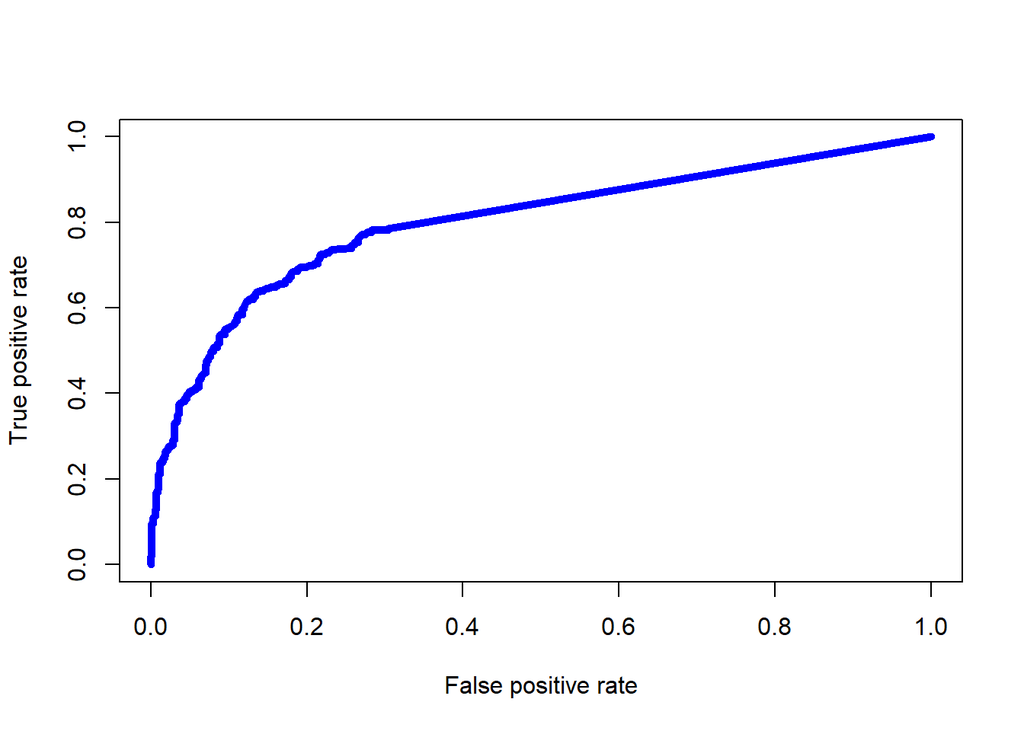

```r
# Plota curva ROC
performance = performance(pred.val, "tpr", "fpr")
plot(performance, col = "blue", lwd = 5)
```

```r
#Calculo Estatística KS
ks <- max(attr(performance,
               "y.values")[[1]] - (attr(performance,
                                        "x.values")[[1]]))
ks
```

```
## [1] 0.5074191
```

Poderíamos usar uma matriz de confusão também, porém precisaríamos definir o corte usado na projeção para dizer se o e-mail é spam ou não. Aqui, vamos trabalhar com 0.5:

```r
#confusion matrix
table(teste$type,
      pred.Teste > 0.5)
```

```
##
##           FALSE TRUE
##   nonspam   648   49
##   spam      247  206
```

Os códigos aqui inseridos se destinam muito mais a quem já tem alguma familiaridade com o conceito de regressão logística e as métricas de avaliação de um modelo. Para os que não compreenderam muita coisa, fiquem tranquilos que em breve solto um material de regressão logística e todas essas métricas de avaliação de performance do modelo.

Se tiver qualquer dúvida, sugestão ou crítica, deixe seu comentário. É importante para eu tentar manter um bom nível de posts no blog!

Abraços e bons estudos!